# Storm Data Analysis - Identify Severe weather events which cause the most harm to human population and which cause the most economic damage

Ashley Machado

January 26, 2016

### Synopsis

This project will involve analysis of Storm Data from U.S. National Oceanic and Atmospheric Administration’s (NOAA) storm database. As part of the analysis, we will try to answer 2 questions: 1. Identify the most harmful weather events,across United States, to the population’s health. and 2. Identify the weather events which have the greatest economic consequences.

The weather events in the database start in the year 1950 and end in November 2011.

### Data pre-processing section:

The storm data, which is in bz2 zipfile format will be read into a R dataframe.

```r
stormDF <- read.csv(bzfile("repdata-data-StormData.csv.bz2"))
```

To answer both the questions, we will subset the dataset to get only the weather event type(EVTYPE), fatalities(FATALITIES), injuries(INJURIES), Property Damage(PROPDMG),Property damage amount’s exponent(PROPDMGEXP), Crop Damage(CROPDMG) and Crop damage amount’s exponent(CROPDMGEXP) columns(variables).

To consolidate(combine) harm done to the population, We will add up the fatalities(FATALITIES) and injuries(INJURIES) to create a new column(variable) - HARM - for the weather event types(EVTYPE).

The property and crop damage amounts have exponent values columns -PROPDMGEXP and CROPDMGEXP. And the exponent values are represented by alphabetical characters - “K” for thousands, “M” for millions, and “B” for billions. We will convert these alphabetical characters to their exponential values and then multiply them to their corresponding damage amounts. Any alphabet character other than - “K”, “M”, “B” - will be coverted to Zero(0) value, which will result in a Zero(0) damage amount.

```r
##Subset only the required columns(variables) from the storm data set.
subsetDF <- subset(stormDF, select = c("EVTYPE","FATALITIES","INJURIES","PROPDMG","PROPDMGEXP","CROPDMG","CROPDMGEXP"))

##Create a new combined population harm column
subsetDF$HARM <- subsetDF$FATALITIES+subsetDF$INJURIES

##Covert exponent representation to actual values and multiply to corresponding damage amounts.
subsetDF <- subsetDF %>% mutate(
    PROPDMGEXP = ifelse (PROPDMGEXP == "K",10^3,
                ifelse (PROPDMGEXP == "M",10^6,
                 ifelse (PROPDMGEXP == "B",10^9,0))) ,

    CROPDMGEXP = ifelse (CROPDMGEXP == "K",10^3,
                ifelse   (CROPDMGEXP == "M",10^6,
               ifelse   (CROPDMGEXP == "B",10^9,0)))
  )
subsetDF$PROPDMG <- subsetDF$PROPDMG*subsetDF$PROPDMGEXP
subsetDF$CROPDMG <- subsetDF$CROPDMG*subsetDF$CROPDMGEXP
```

### Results:

#### Analysis of the weather event’s impact to Human population:

To answer the question of identifying weather events most harmful to human population, we will generate 3 different views for the top 10 harmful weather events.

The first view will be the combined Fatalities and Injuries(count) because of the Weather events.

The second view will be the Fatality(count) because of the weather events.

The Third view will be the Injured(count) because of the weather events.

For these 3 views , dataset will be subsetted(grouped and summarized individually) as per combined(injury and fatality) impact to human population or fatalities or injuries.

A graph will be generated, with subsetted data sets to display the magnitude of harm to human population.

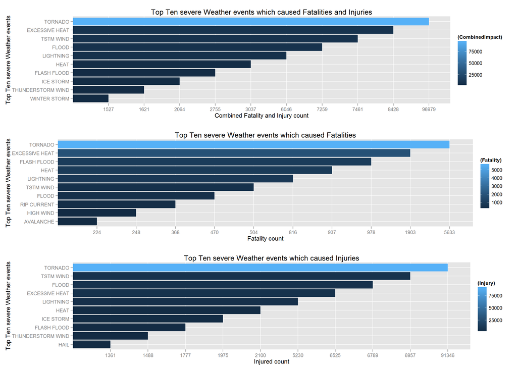

```r
## To subset data for combined harm, summarize and sum up the harm data.
subsetCombHarm <- subsetDF %>% group_by(EVTYPE) %>% summarise(CombinedImpact = sum(HARM)) %>% arrange(desc(CombinedImpact))
### Convert to data frame object
subsetCombHarm <- as.data.frame(subsetCombHarm)
### Order the weather types in descending order
subsetCombHarm$EVTYPE <- factor(subsetCombHarm$EVTYPE, levels = subsetCombHarm[order(subsetCombHarm$CombinedImpact), "EVTYPE"])
### Create a graph using ggplot2 for the top 10 harmful weather events.
firstview <- ggplot(data = subsetCombHarm[1:10,], aes(x=EVTYPE,
    y=reorder(CombinedImpact, -table(CombinedImpact)[CombinedImpact])
    , fill=(CombinedImpact))) +      geom_bar(position="dodge",stat="identity") + coord_flip() +
  ggtitle("Top Ten severe Weather events which caused Fatalities and Injuries")+
  ylab("Combined Fatality and Injury count")+
  xlab("Top Ten severe Weather events")

## To subset data for Fatalities, summarize and sum up the fatality data.
subsetFatalHarm <- subsetDF %>% group_by(EVTYPE) %>% summarise(Fatality = sum(FATALITIES)) %>% arrange(desc(Fatality))
### Convert to data frame object
subsetFatalHarm <- as.data.frame(subsetFatalHarm)
### Order the weather types in descending order
subsetFatalHarm$EVTYPE <- factor(subsetFatalHarm$EVTYPE, levels = subsetFatalHarm[order(subsetFatalHarm$Fatality), "EVTYPE"])
### Create a graph using ggplot2 for the top 10 harmful weather events.
secondview <- ggplot(data = subsetFatalHarm[1:10,], aes(x=EVTYPE,
    y=reorder(Fatality, -table(Fatality)[Fatality])
    , fill=(Fatality))) +      geom_bar(position="dodge",stat="identity") + coord_flip() +
  ggtitle("Top Ten severe Weather events which caused Fatalities")+
  ylab("Fatality count")+
  xlab("Top Ten severe Weather events")

## To subset data for Injuries, summarize and sum up the Injury data.
subsetInjuryHarm <- subsetDF %>% group_by(EVTYPE) %>% summarise(Injury = sum(INJURIES)) %>% arrange(desc(Injury))
### Convert to data frame object
subsetInjuryHarm <- as.data.frame(subsetInjuryHarm)
### Order the weather types in descending order
subsetInjuryHarm$EVTYPE <- factor(subsetInjuryHarm$EVTYPE, levels = subsetInjuryHarm[order(subsetInjuryHarm$Injury), "EVTYPE"])
### Create a graph using ggplot2 for the top 10 harmful weather events.
thirdview <- ggplot(data = subsetInjuryHarm[1:10,], aes(x=EVTYPE,
    y=reorder(Injury, -table(Injury)[Injury])
    , fill=(Injury))) +      geom_bar(position="dodge",stat="identity") + coord_flip() +
  ggtitle("Top Ten severe Weather events which caused Injuries")+
  ylab("Injured count")+
  xlab("Top Ten severe Weather events")

##Display the grid.
grid.arrange(firstview,secondview,thirdview)
```

#### Analysis of the weather event’s economic impact:

To answer the question of identifying the weather events which have the greatest economic consequences. we will generate 3 different views for top 10 severe weather events.

The First view will be the property damage cost because of the weather events.

The Second view will be the Crop damage cost because of the weather events.

The Third view will be the Combined Property and Crop damage cost because of the weather events.

For these 3 views, dataset will be subsetted(grouped and summarized individually) as per property damage cost or crop damage cost or combined(property and crop) damage cost.

A graph will be generated, with subsetted data sets to display the magnitude of each cost.

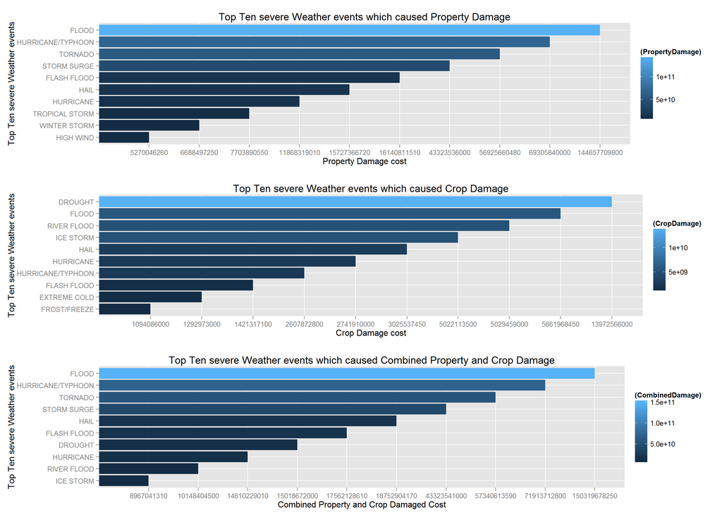

```r
## To subset data for Property Damage, summarize and sum up the property damage cost data.
PropDmgDF <- subsetDF %>% group_by(EVTYPE) %>% summarise(PropertyDamage = sum(PROPDMG)) %>% arrange(desc(PropertyDamage))
### Convert to data frame object
PropDmgDF <- as.data.frame(PropDmgDF)
### Order the weather types in descending order
PropDmgDF$EVTYPE <- factor(PropDmgDF$EVTYPE, levels = PropDmgDF[order(PropDmgDF$PropertyDamage), "EVTYPE"])
### Create a graph using ggplot2 for the top 10 harmful weather events.
First <- ggplot(data = PropDmgDF[1:10,], aes(x=EVTYPE,
    y=reorder(PropertyDamage, -table(PropertyDamage)[PropertyDamage])
    , fill=(PropertyDamage))) +      geom_bar(position="dodge",stat="identity") + coord_flip() +
  ggtitle("Top Ten severe Weather events which caused Property Damage")+
  ylab("Property Damage cost")+
  xlab("Top Ten severe Weather events")


## To subset data for Property Damage, summarize and sum up the Crop damage cost data.
CropDmgDF <- subsetDF %>% group_by(EVTYPE) %>% summarise(CropDamage = sum(CROPDMG)) %>% arrange(desc(CropDamage))
### Convert to data frame object
CropDmgDF <- as.data.frame(CropDmgDF)
### Order the weather types in descending order
CropDmgDF$EVTYPE <- factor(CropDmgDF$EVTYPE, levels = CropDmgDF[order(CropDmgDF$CropDamage), "EVTYPE"])
### Create a graph using ggplot2 for the top 10 harmful weather events.
Second <- ggplot(data = CropDmgDF[1:10,], aes(x=EVTYPE,
    y=reorder(CropDamage, -table(CropDamage)[CropDamage])
    , fill=(CropDamage))) +      geom_bar(position="dodge",stat="identity") + coord_flip() +
  ggtitle("Top Ten severe Weather events which caused Crop Damage")+
  ylab("Crop Damage cost")+
  xlab("Top Ten severe Weather events")


## To subset data for Property Damage, summarize and sum up the Crop damage cost data.
subsetDF$CombDmg <- subsetDF$PROPDMG+subsetDF$CROPDMG
CombDmgDF <- subsetDF %>% group_by(EVTYPE) %>% summarise(CombinedDamage = sum(CombDmg)) %>% arrange(desc(CombinedDamage))
### Convert to data frame object
CombDmgDF <- as.data.frame(CombDmgDF)
### Order the weather types in descending order
CombDmgDF$EVTYPE <- factor(CombDmgDF$EVTYPE, levels = CombDmgDF[order(CombDmgDF$CombinedDamage), "EVTYPE"])
### Create a graph using ggplot2 for the top 10 harmful weather events.
Third <- ggplot(data = CombDmgDF[1:10,], aes(x=EVTYPE,
    y=reorder(CombinedDamage, -table(CombinedDamage)[CombinedDamage])
    , fill=(CombinedDamage))) +      geom_bar(position="dodge",stat="identity") + coord_flip() +
  ggtitle("Top Ten severe Weather events which caused Combined Property and Crop Damage")+
  ylab("Combined Property and Crop Damaged Cost")+
  xlab("Top Ten severe Weather events")

##Display the grid.
grid.arrange(First,Second,Third)
```

### Summary:

Below are the summarized findings of the data analysis done to identity the impact of severe weather events on human population and the economic damage they cause.

The severe weather event which caused the maximum combined harm(Fatalities and Injuries) to human population is TORNADO.

The severe weather event which caused the maximum Fatality is TORNADO.

The severe weather event which caused the maximum Injury is TORNADO.

The severe weather event which caused the maximum property damage is FLOOD.

The severe weather event which caused the maximum Crop damage is DROUGHT.

The severe weather event which caused the maximum combined economic(crop and property) damage is FLOOD.